# Introduction to Keras

February 2, 2018

# Introduction

I am using an example from the book [Deep Learning with R](https://www.amazon.com/Deep-Learning-Python-Francois-Chollet/dp/1617294438/ref=sr_1_2_sspa?ie=UTF8&qid=1518203515&sr=8-2-spons&keywords=deep+learning+R&psc=1). The text is an excellent introduction to Deep Learning and uses the widely praised Keras platform.

The following example is available [here](https://github.com/jjallaire/deep-learning-with-r-notebooks). I am going to adapt it for myself.

```r
library(keras)
library(tidyverse)
library(imager)

mnist <- dataset_mnist()
train_images <- mnist$train$x
train_labels <- mnist$train$y
test_images <- mnist$test$x
test_labels <- mnist$test$y
```

We see that we have an array of 60000, 28x28 matrices. Each matrix contains a handwritten digit.

```r
str(train_images)
```

```
##  int [1:60000, 1:28, 1:28] 0 0 0 0 0 0 0 0 0 0 ...
```

```r
str(train_labels)
```

```
##  int [1:60000(1d)] 5 0 4 1 9 2 1 3 1 4 ...
```

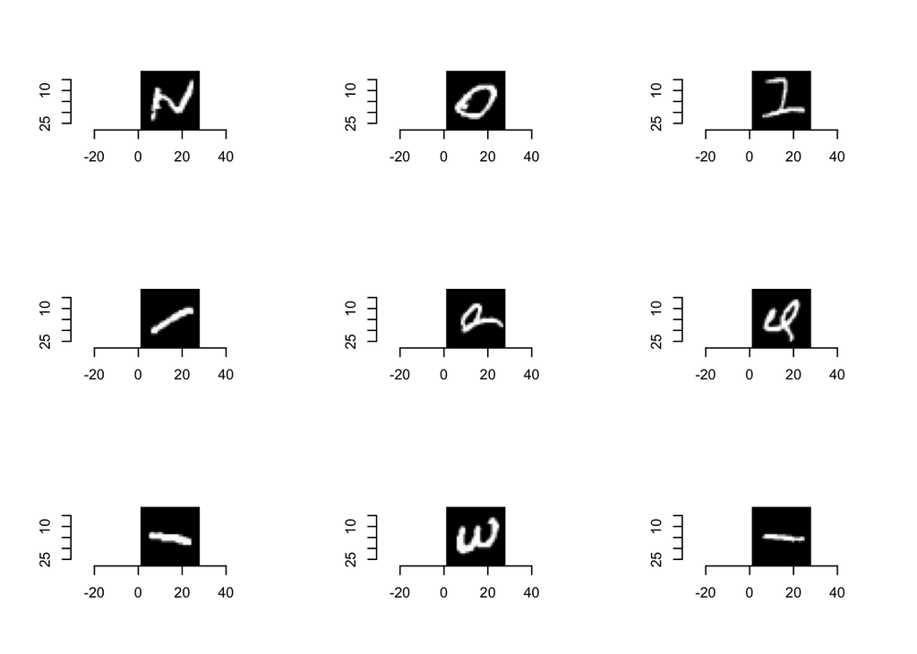

```r
par(mfrow = c(3, 3) )
for(i in 1:9) {
  train_images[i,,] %>%
  as.cimg %>%
  plot
}
```

```r
par(mfrow = c(1, 1) )
```

# Building the Model

Before we use any of the inputs, we build the model out. These steps are done in place. Keras is built on top of python code and works a bit differently than R.

```r
network <- keras_model_sequential() %>%
  layer_dense(units = 512, activation = "relu", input_shape = c(28 * 28)) %>%
  layer_dense(units = 10, activation = "softmax")

network %>% compile(
  optimizer = "rmsprop",
  loss = "categorical_crossentropy",
  metrics = c("accuracy")
)
```

# Reshaping the Array

Next, we reshape the 3D arrays into a 2D matrix and normalize the values to fall between 0 and 1.

```r
train_images  <-
  train_images %>%
   array_reshape(
     c(
       60000,
       28 * 28
     )
   )

train_images <-
   train_images / 255

test_images  <-
  test_images %>%
  array_reshape(
    c(
      10000,
      28 * 28
    )
  )

test_images <-
   test_images / 255
```

# Encoding the labels.

Next we turn the numeric labels into categorical/binary labels.

```r
head(train_labels)
```

```
## [1] 5 0 4 1 9 2
```

```r
train_labels <-
  train_labels %>%
  to_categorical()

test_labels <-
  test_labels %>%
  to_categorical()
```

```r
train_labels %>%
  apply(2, FUN = function(x) ifelse(x == 1, 1, "")) %>%
  head %>%
  noquote()
```

```
##      [,1] [,2] [,3] [,4] [,5] [,6] [,7] [,8] [,9] [,10]
## [1,]                          1
## [2,] 1
## [3,]                     1
## [4,]      1
## [5,]                                              1
## [6,]           1
```

We’re now ready to train the network, which in Keras is done via a call to the network’s fit method: we fit the model to its training data.

# Training the Model.

```r
network %>%
  fit(train_images, train_labels, epochs = 5, batch_size = 128)
```

# Getting the metrics.

```r
metrics  <-
  network %>%
  evaluate(test_images, test_labels)
```

# Generating Predictions

```r
predictions <-
  network %>%
  predict_classes(test_images)
```

# Evaluating Model Accuracy

```r
actual_values <-
  test_labels %>%
  apply(1, FUN = function(x) (1:10)[x==1])
```

## Checking it out

We see here a very strong diagonal and accuracy of almost 98 percent!

```r
table_predictions <-
  table(predictions, actual_values)

table_predictions
```

```
##            actual_values
## predictions    1    2    3    4    5    6    7    8    9   10
##           0  970    0    1    0    1    3    5    1    3    3
##           1    0 1126    1    0    0    0    2    6    0    2
##           2    2    3 1013    4    4    0    3   10    4    1
##           3    1    1    4  997    0   12    1    3    6    8
##           4    1    0    1    0  967    1    4    1    4   12
##           5    1    0    0    1    0  869    3    0    1    1
##           6    2    2    2    0    2    2  938    0    0    0
##           7    1    0    4    2    0    0    0  994    2    2
##           8    1    3    6    2    1    4    2    4  949    3
##           9    1    0    0    4    7    1    0    9    5  977
```

```r
sum(diag(table_predictions))/sum(table_predictions)
```

```
## [1] 0.98
```